# Part One QUESTION BASED

```python
import math
import numpy as np
import pandas as pd
```

# Question 1

```python
df = pd.DataFrame({
        "Placed an Order":[400,200],
        "Didn't place order":[100,1300]
    },
    index=['yes','no']
)
df
```

|  | Placed an Order | Didn't place order |
| --- | --- | --- |
| yes | 400 | 100 |
| no | 200 | 1300 |

> **1.1** Refer to the above table and find the joint probability of the people who planned to purchase and actually placed an order

```python
df['Placed an Order'].loc['yes']/df.sum().sum()
```

```
0.2
```

> **1.2** Refer to the above table and find the joint probability of the people who planned to purchase and actually placed an order, given that people planned to purchase

```python
df['Placed an Order'].loc['yes']/df.loc['yes'].sum()
```

```
0.8
```

# Question 2

> An electrical manufacturing company conducts quality checks at specified periods on the products it manufactures. Historically, the failure rate for the manufactured item is 5%. Suppose a random sample of 10 manufactured items is selected. Answer the following questions.

```python
def p_defective(defective_item_count,total_items,probability_of_defectiveness):
    nCr = math.comb(total_items,defective_item_count)
    return (probability_of_defectiveness**defective_item_count) * \
            ((1-probability_of_defectiveness)**(total_items-defective_item_count)) * nCr
```

```python
def p_list(defective_item_counts,total_items,probability_of_defectiveness):
    p_sum = 0.0
    for defective_item_count in defective_item_counts:
#         print("*"*20)
#         print(defective_item_count)
        p = p_defective(defective_item_count,total_items,probability_of_defectiveness)
#         print(p)
        p_sum += p
    return p_sum
```

> 2.A . Probability that none of the items are defective?

```python
p_defective(0,10,0.05)
```

```
0.5987369392383787
```

> 2.B Probability that exactly one of the items is defective?

```python
p_defective(1,10,0.05)
```

```
0.31512470486230454
```

> 2.C Probability that two or fewer of the items are defective?

```python
p_list(range(3),10,0.05)
```

```
0.9884964426207028
```

> 2.D Probability that three or more of the items are defective ?

```python
p_list(range(3,11),10,0.05)
```

```
0.011503557379296871
```

# Question 3

> A car salesman sells on an average 3 cars per week.

```python
import matplotlib.pyplot as plt
from scipy.stats import poisson
```

> 3.A Probability that in a given week he will sell some cars.

```python
1-poisson.pmf(0,3)
```

```
0.950212931632136
```

> 3.B Probability that in a given week he will sell 2 or more but less than 5 cars.

```python
poisson.pmf(2,3)+poisson.pmf(3,3)+poisson.pmf(4,3)
```

```
0.6161149710523164
```

> 3.C Plot the poisson distribution function for cumulative probability of cars sold per-week vs number of cars sold perweek

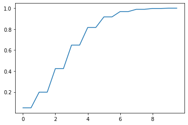

```python
x = np.arange(0,10,0.5)
y = poisson.cdf(x,3)
plt.plot(x,y)
```

# Question 4

> Accura in understanding orders for a speech based bot at a restaurant is important for the Company X which has designed, marketed and launched the product for a contactless delivery due to the COVID-19 pandemic. Recognition accuracy that measures the percentage of orders that are taken correctly is 86.8%. Suppose that you place order with the bot and two friends of yours independently place orders with the same bot. Answer the following questions.

```python
from scipy.stats import binom
```

> 4.A What is the probability that all three orders will be recognised correctly?

```python
binom.pmf(3,3,0.868)
```

```
0.653972032
```

> 4.B What is the probability that none of the three orders will be recognised correctly?

```python
binom.pmf(0,3,0.868)
```

```
0.002299968
```

```python
binom.cdf(2,3,0.868)
```

```
0.346027968
```

# Question 5

> A group of 300 professionals sat for a competitive exam. The results show the information of marks obtained by them have a mean of 60 and a standard deviation of 12. The pattern of marks follows a normal distribution. Answer the following questions.

```python
from scipy.stats import norm
```

```python
x = np.arange(0,100,1)
y = norm.pdf(x,60,12)
z = norm.cdf(x,60,12)
```

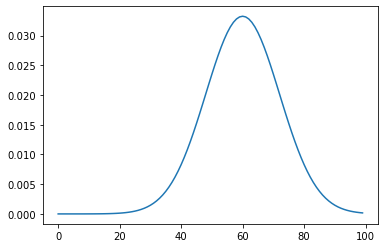

```python
plt.plot(x,y)
```

> 5.A What is the percentage of students who score more than 80.

```python
1-norm.cdf(80,60,12)
```

```
0.047790352272814696
```

> 5.B What is the percentage of students who score less than 50.

```python
norm.cdf(50,60,12)
```

```
0.20232838096364308
```

> 5.C What should be the distinction mark if the highest 10% of students are to be awarded distinction?

```python
norm.ppf(0.9,60,12)
```

```
75.3786187865352
```

# Question 6

> Explain 1 real life industry scenario [other than the ones mentioned above] where you can use the concepts learnt in this module of Applied statistics to get a data driven business solution.

> SOLUTION: According to me the real life scenario would be the stocks markets in which we can apply the applied statistics where the tons of stocks which we can consider as data and we can take one of the stock and can apply stattics over it in means of when the stock was up when the stock was down. How much loss the particular stock has taken. How much profit the particular stock has made.How many people buy that stock.How many people sell that stock.What higher percentage that particualar stock has gone.